# Portfolio Week 11

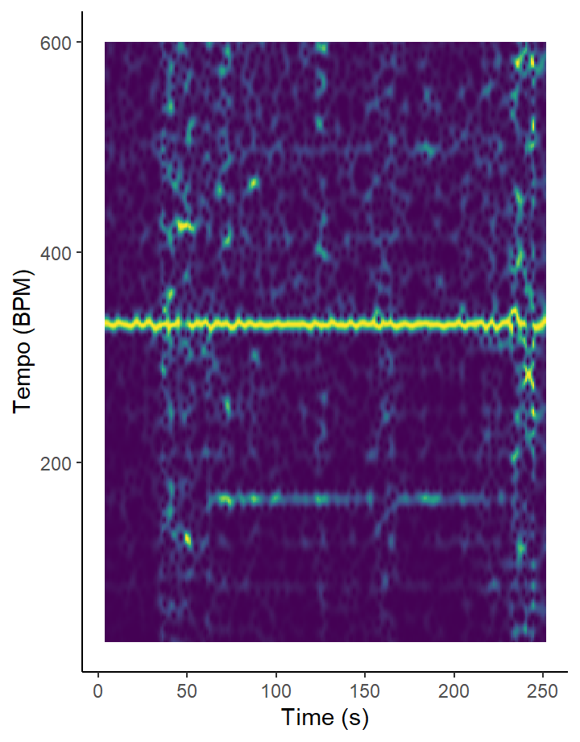

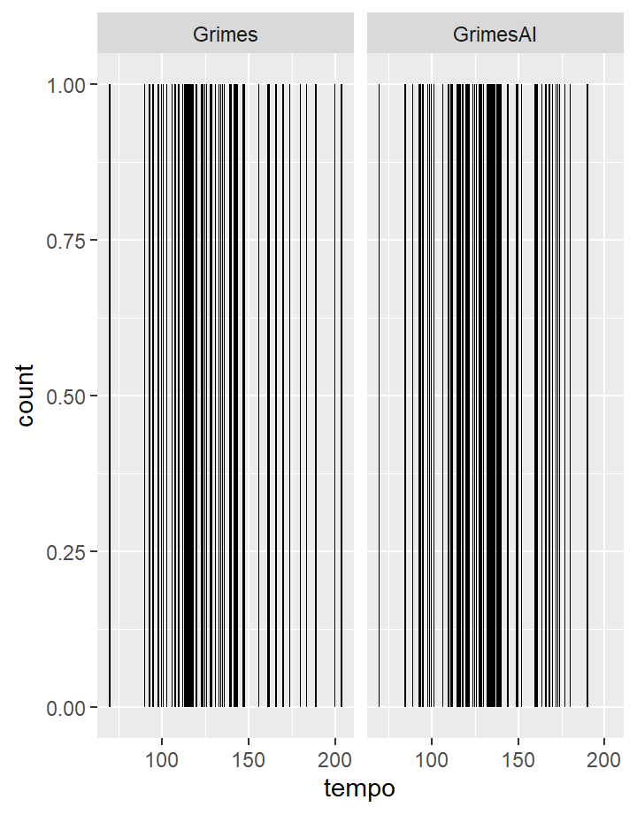

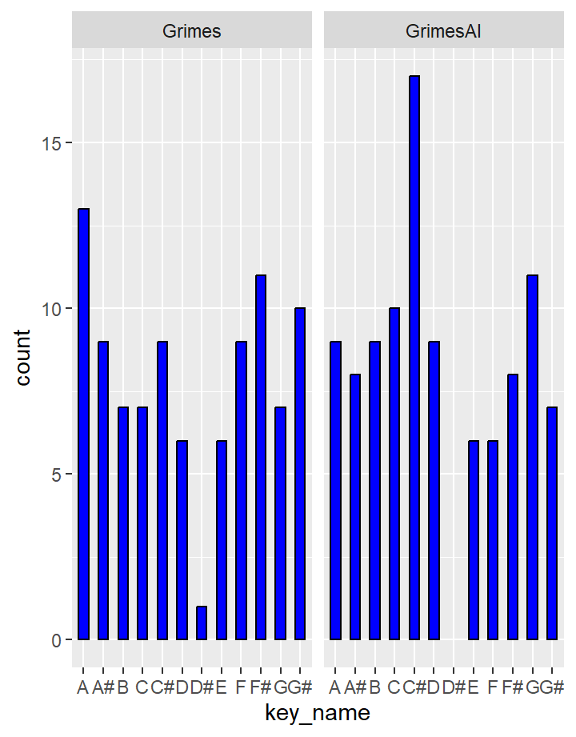

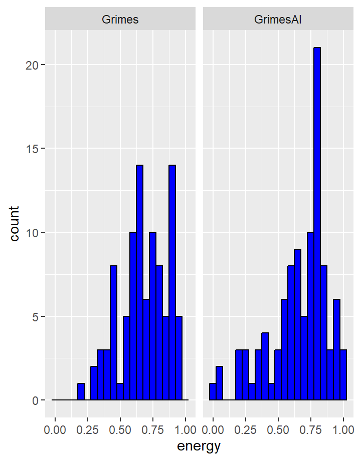

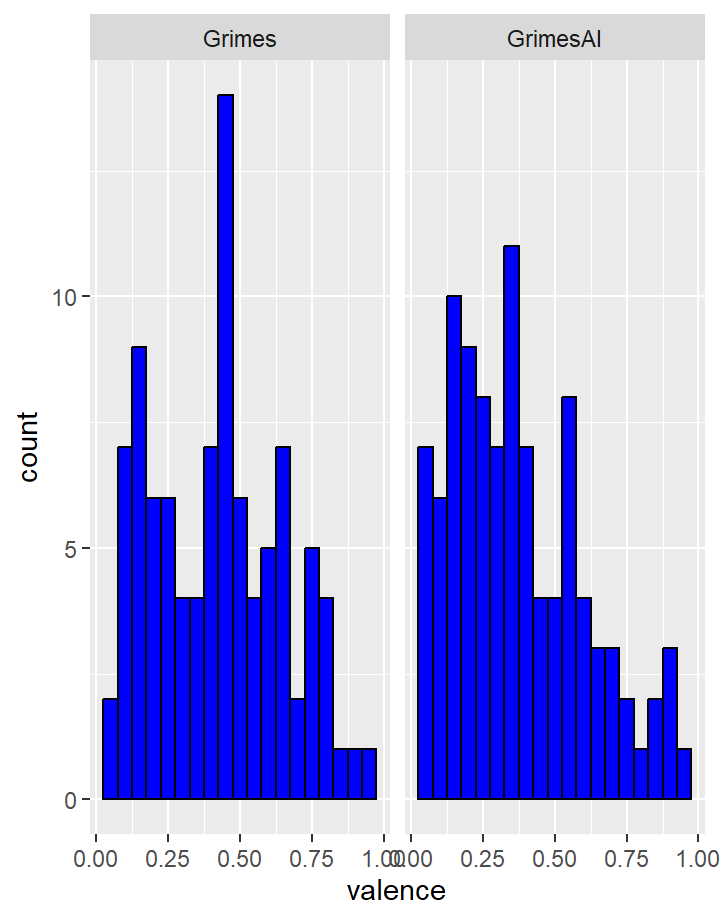

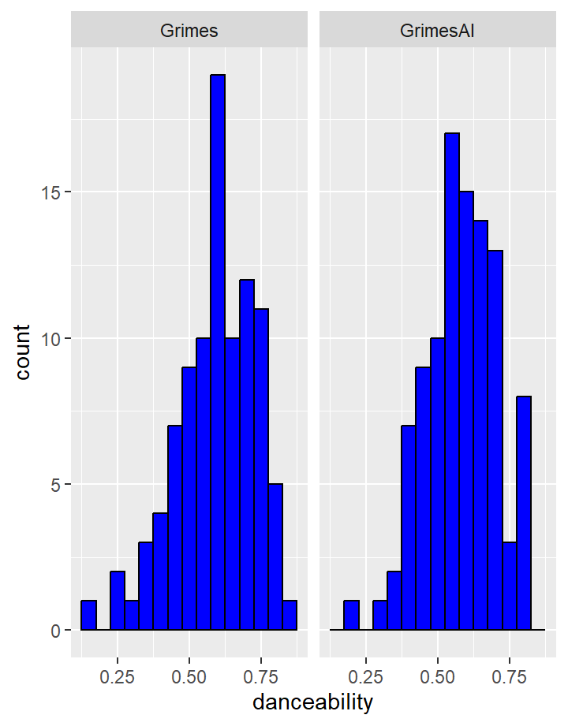

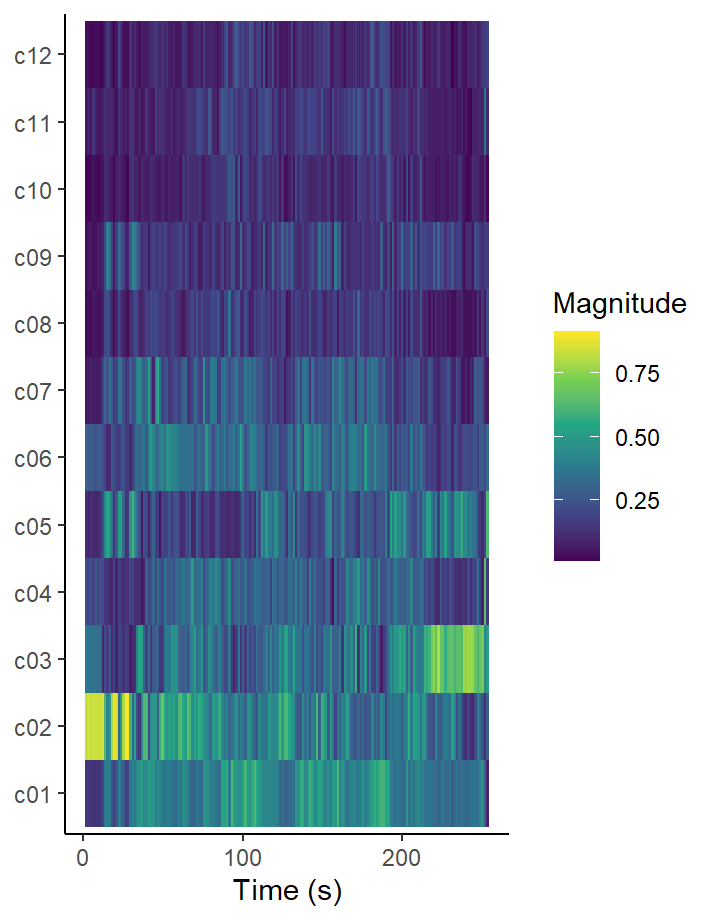

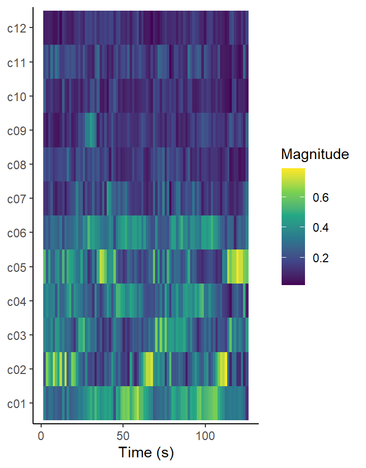

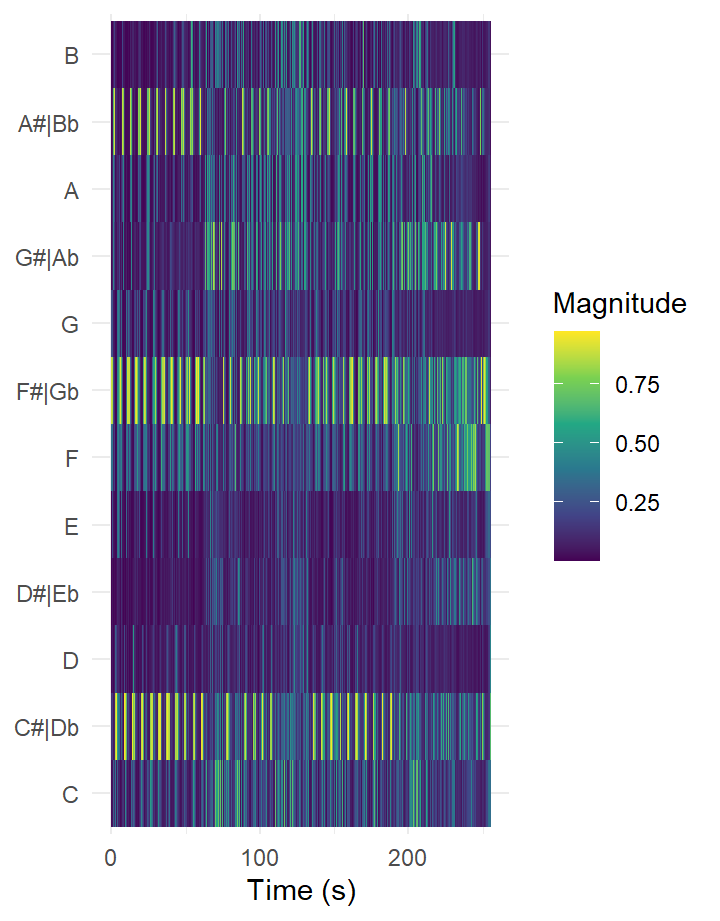

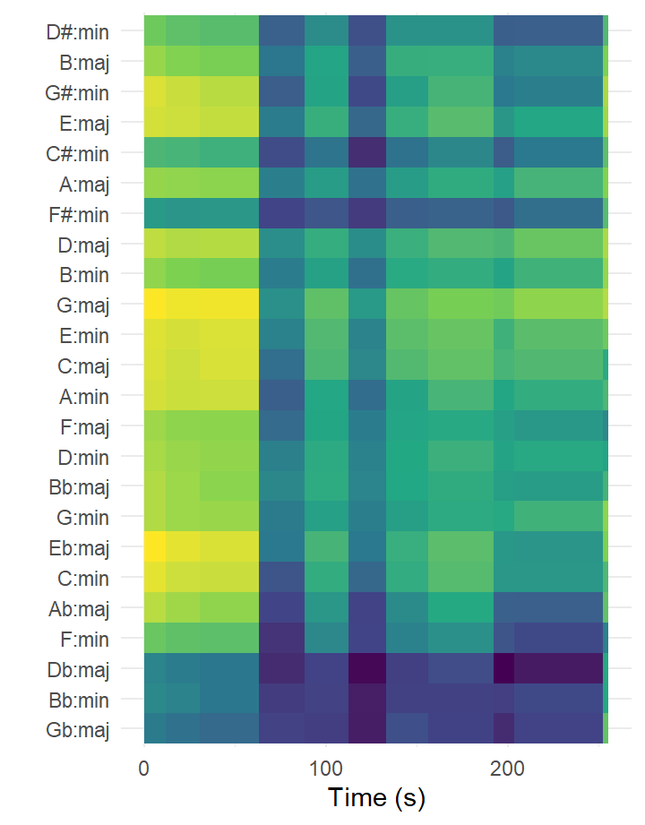

# Tempogram

### **Tempogram (Genesis - Grimes)**

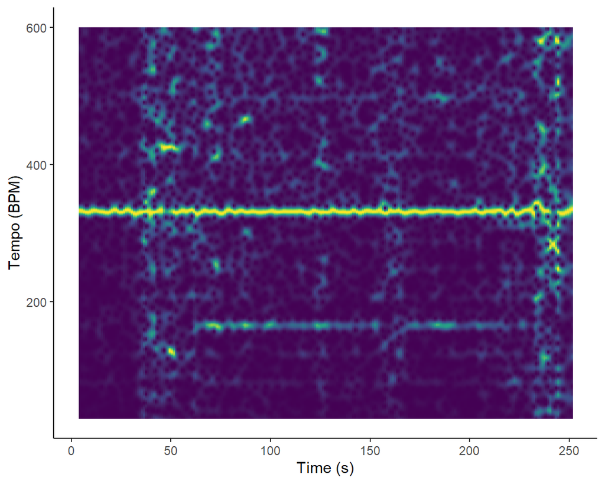

### **Analysis**

The song “Genesis” by Grimes has a very steady beat throughout the track, which can be observed in the tempogram. At around 0:40 the vocals of the song start, which leads to some different tempi being picked up and displayed in the tempogram. At around 3:50, the steady beat that can be heard throughout the song stops and the song ends with airy singing and a piano melody. In the tempogram, this can be observed as the steady beat around 340 bpm becoming less clear.

# Tempo Histogram

### **Tempo Histogram**

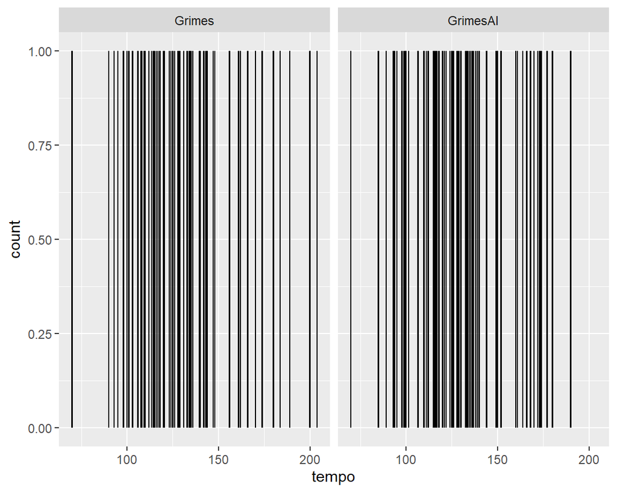

### **Analysis**

Just like the sitribution of keys, GrimesAI also shows less varietyin tempi compared to Grimes. This could be interpreted, as AI songs being less “original” or unique than regularly produced songs. Additionally, GrimesAI songs are also a bit faster than the Grime’s counterparts. There is a high occurence of songs with a tempo of around 140 bpm, while for Grime’s songs the most occuring tempo is about 110 bpm.

# Key Histogram

### **Keys Histogram**

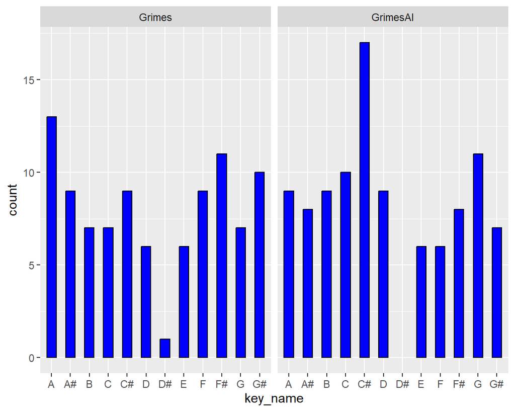

# Introduction

## Introduction

### **Introduction**

My corpus consists of two playlists, of which one features 95 Grimes songs and the other one 100 GrimesAI songs. Grimes is a Canadian musician known for her futuristic sounds and approaches to music production. GrimesAI is a project under which AI generated songs using Grime’s voice are being released on Spotify. Anyone can generate songs featuring Grime’s voice with the help of ElfTech, a generative AI system trained on the artist’s voice. By comparing the two playlists, I will be able to directly compare songs by the “real” Grimes and songs imitating her. I am intrigued to see if the use of her voice will automatically make other aspects of the songs, like the energy or valence level. similar. I want to explore if music generative AI systems stick to the base points of the songs they were trained on or if they really create something entirely new.

# Visualisation 1

### **Energy**

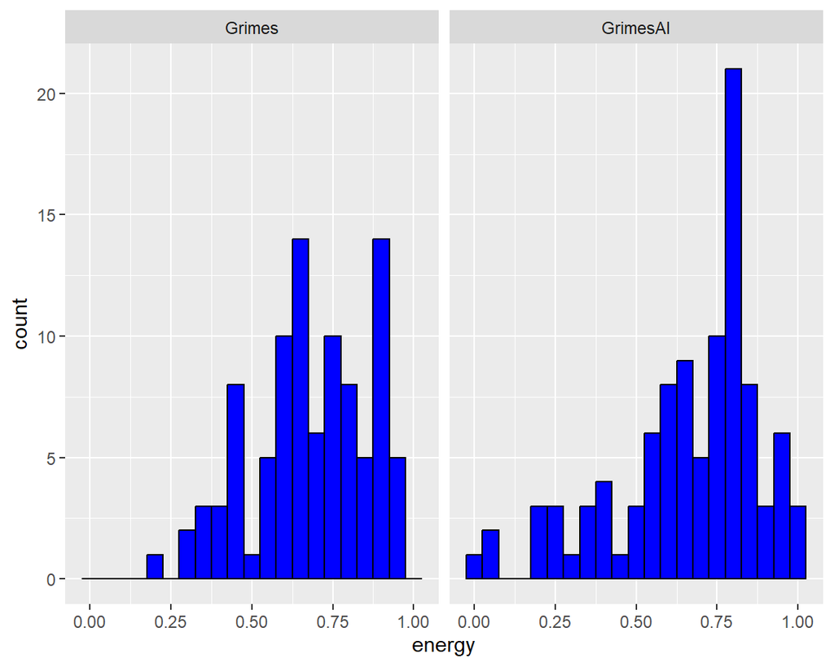

# Visualisation 2

### **Valence**

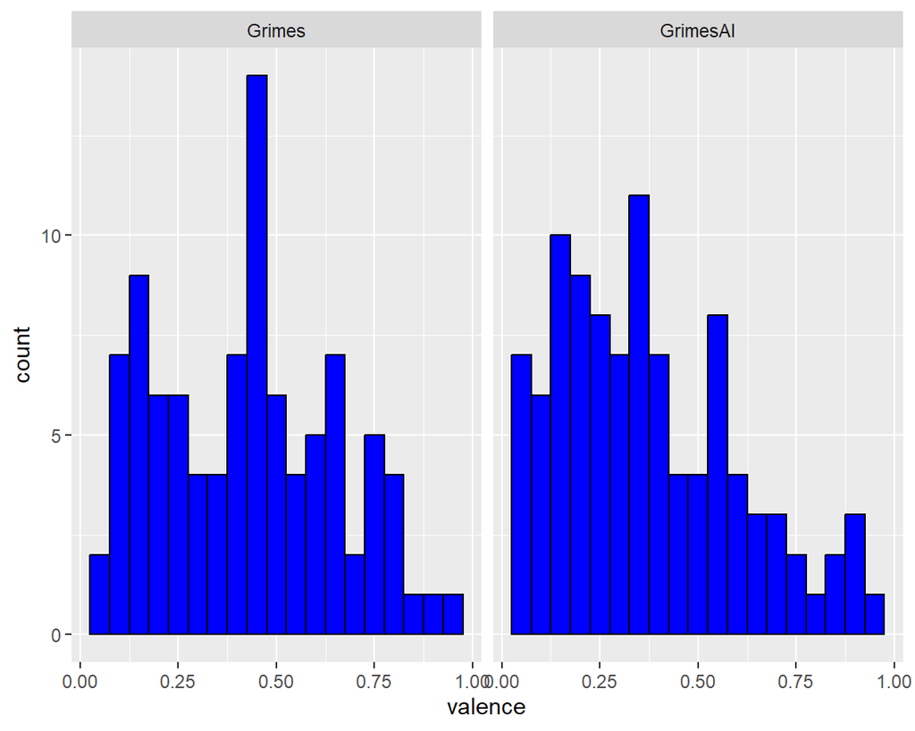

# Visualisation 3

### **Danceability**

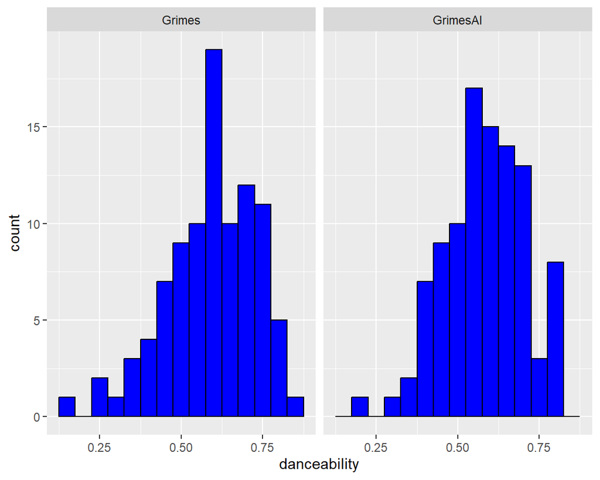

# Visualisation 5

### **Genesis - Grimes (Timbre)**

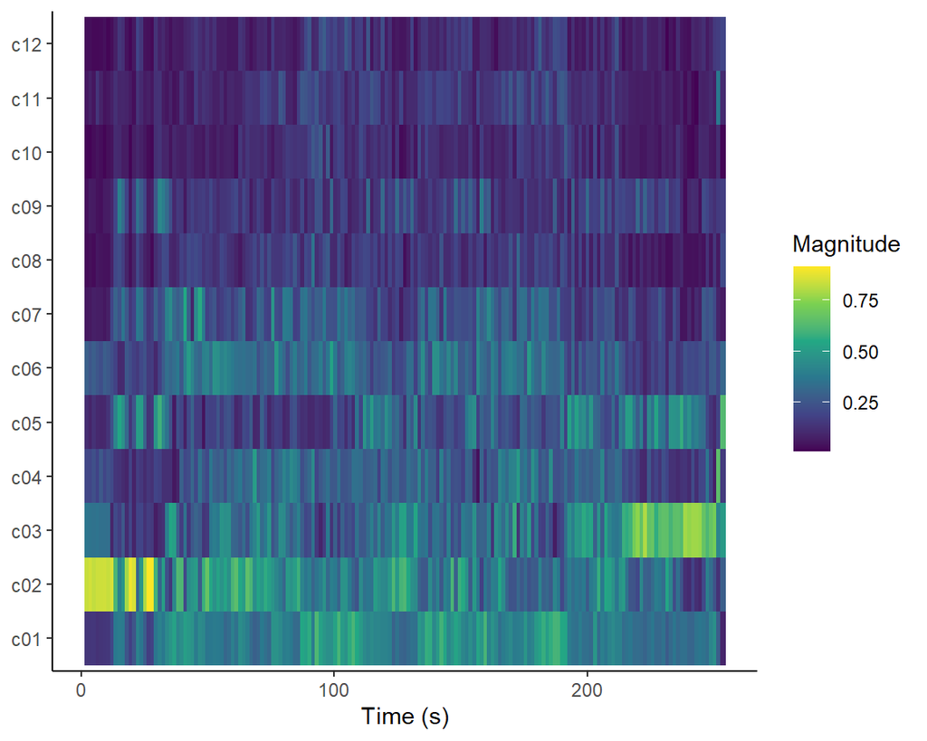

### **Cold Touch - GrimesAI (Timbre)**

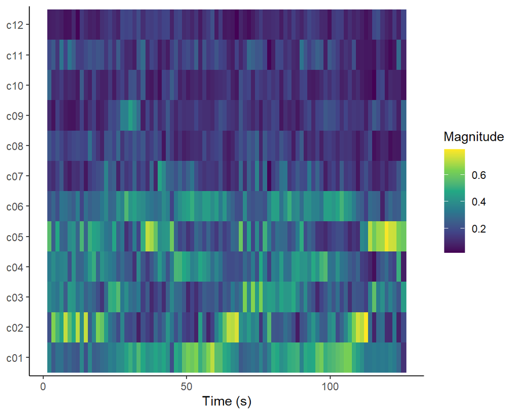

# Visualisation 6

### **Genesis - Grimes (Chroma)**

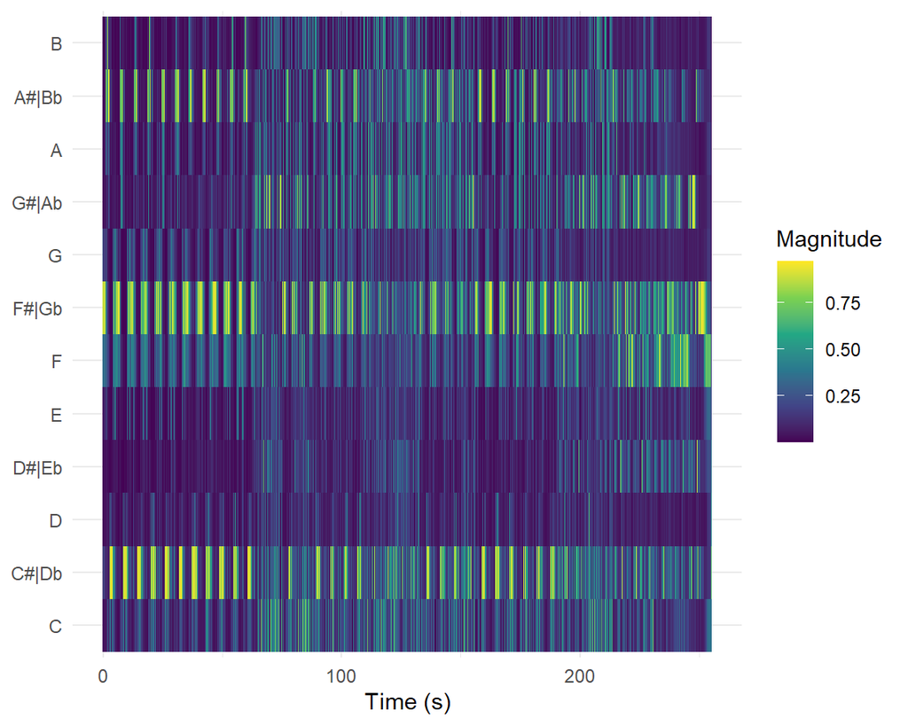

# Visualisation 7

### **Genesis - Grimes (Pitch)**

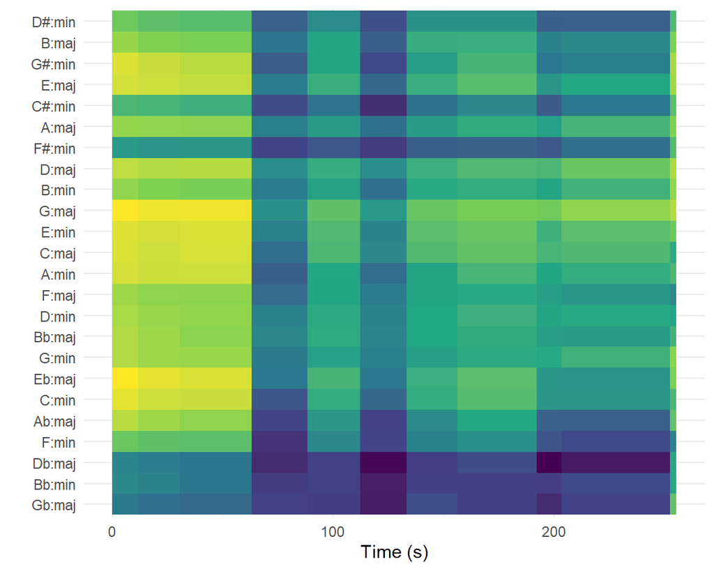

# Discussion